# Q3

```python
import numpy as np
import matplotlib.pyplot as plt
from tensorflow.keras.models import Sequential
from tensorflow.keras.layers import LSTM, GRU, Dense
```

```python
# Generate the Sine wave data
np.random.seed(0)
sequence_length = 1000
X = np.random.uniform(low=-np.pi, high=np.pi, size=(sequence_length, 1))
y = np.sin(X)
# Split the data into training and testing sets
train_size = int(0.8 * sequence_length)
X_train, X_test = X[:train_size], X[train_size:]
y_train, y_test = y[:train_size], y[train_size:]
# Reshape the input data for LSTM
X_train = X_train.reshape((X_train.shape[0], X_train.shape[1], 1))
X_test = X_test.reshape((X_test.shape[0], X_test.shape[1], 1))
```

```python
# Build the LSTM model
lstm_model = Sequential()
lstm_model.add(LSTM(32, return_sequences=True, input_shape=(X_train.shape[1], X_train.shape[2])))
lstm_model.add(LSTM(64))
lstm_model.add(Dense(128))
lstm_model.add(Dense(1))
lstm_model.compile(loss='mean_squared_error', optimizer='adam')

# Train the LSTM model
lstm_model.fit(X_train, y_train, epochs=50, batch_size=16)
```

```
<keras.callbacks.History at 0x30381aa10>
```

```python
lstm_model.summary()
```

```
Model: "sequential_10"
_________________________________________________________________
 Layer (type)                Output Shape              Param #
=================================================================
 lstm_5 (LSTM)               (None, 1, 32)             4352

 lstm_6 (LSTM)               (None, 64)                24832

 dense_14 (Dense)            (None, 128)               8320

 dense_15 (Dense)            (None, 1)                 129

=================================================================
Total params: 37,633
Trainable params: 37,633
Non-trainable params: 0
_________________________________________________________________
```

## Model Archetctures

LSTM layer: The LSTM layer is added to the model using the LSTM function. It has 32 units, which determines the dimensionality of the output space. The input_shape parameter is passed to the first LSTM layer to define the shape of the input data. LSTM(64): This is the second LSTM layer in the model. It has 64 units. Since return_sequences is not specified, it defaults to False, meaning that this layer will not return the output sequence.

Dense layer: After the LSTM layer,Dense(128) is a fully connected dense layer with 128 units. It takes the output of the previous layer (which is the output of the last LSTM layer) and applies a linear transformation to produce a new representation. Then a Dense layer with 1 unit is added. This layer is responsible for generating the final output of the model.

Compilation: The model is compiled using the compile method. The loss function is set to 'mean_squared_error', which is suitable for regression tasks. The optimizer is set to 'adam', which is a popular optimization algorithm.

Training: The model is trained using the fit method, where X_train and y_train are used as the training data. The model is trained for 50 epochs with a batch size of 16.

Loss function (mean_squared_error): The loss function used in the model is mean squared error (MSE). MSE is a common choice for regression tasks, where the goal is to minimize the difference between predicted and true values. It squares the differences between predicted and true values, giving higher weights to larger errors. The choice of MSE is suitable for this regression problem of predicting the sine wave values.

Optimizer (adam): The optimizer used in the model is Adam. Adam is an adaptive learning rate optimization algorithm that combines ideas from both AdaGrad and RMSProp. It dynamically adjusts the learning rate during training, allowing for faster convergence and better handling of different learning rates for different parameters. Adam is a popular choice for deep learning models as it often yields good results with relatively less manual tuning.

## Hypreparameters

LSTM_3 units (32): The number of LSTM units determines the dimensionality of the output space of the LSTM layer. In this case, 32 LSTM units have been chosen. The choice of the number of units depends on the complexity of the problem. Increasing the number of units allows the model to capture more complex patterns in the data but also increases the computational requirements and potential overfitting risk. The choice of 32 units strikes a balance between complexity and efficiency for this specific problem.

Number of epochs (50): The number of epochs determines how many times the model will iterate over the entire training dataset during training. Each epoch consists of forward and backward passes through the network, updating the weights. The choice of the number of epochs depends on the complexity of the problem, the size of the dataset, and the convergence of the model. In this case, 50 epochs have been chosen, which allows the model to make multiple passes over the data while not being too computationally expensive.

Batch size (16): The batch size specifies the number of samples used in each forward and backward pass during training. It determines the number of samples that will be propagated through the network before updating the weights. The choice of batch size affects the trade-off between computational efficiency and model convergence. Smaller batch sizes can provide more accurate weight updates but can be slower due to more frequent weight updates. In this case, a batch size of 16 has been chosen, which is a relatively small batch size suitable for this problem size.

## Number of parameters

Number of parameters = Number of units in the layer * Number of inputs to each unit + Number of biases in the layer

```python
# Build the GRU model
gru_model = Sequential()
gru_model.add(GRU(64, return_sequences=True, input_shape=(X_train.shape[1], X_train.shape[2])))
gru_model.add(GRU(128))
gru_model.add(Dense(32))
gru_model.add(Dense(1))
gru_model.compile(loss='mean_squared_error', optimizer='adam')

# Train the GRU model
gru_model.fit(X_train.reshape((X_train.shape[0], X_train.shape[1], 1)), y_train, epochs=50, batch_size=16)
```

```
<keras.callbacks.History at 0x3066951e0>
```

```python
gru_model.summary()
```

```
Model: "sequential_11"
_________________________________________________________________
 Layer (type)                Output Shape              Param #
=================================================================
 gru_11 (GRU)                (None, 1, 64)             12864

 gru_12 (GRU)                (None, 128)               74496

 dense_16 (Dense)            (None, 32)                4128

 dense_17 (Dense)            (None, 1)                 33

=================================================================
Total params: 91,521
Trainable params: 91,521
Non-trainable params: 0
_________________________________________________________________
```

## Model Archetctures

GRU layer: GRU Units (64, 128): The number of units in the GRU layers determines the capacity and complexity of the model. Increasing the number of units allows the model to learn more intricate patterns and relationships in the data. However, it also increases the model's computational complexity and memory requirements. In this case, 64 and 128 units are chosen based on the assumption that the problem requires a moderately complex representation to capture important features.

Dense layer: Dense Units (32): The number of units in the dense layer determines the complexity of the learned representation after the GRU layers. Adding a dense layer after the GRU layers helps to further refine and transform the extracted features. The choice of 32 units is a heuristic value that can be adjusted based on the complexity of the problem and the available computational resources. Dense Units (1): The final layer is a fully connected layer with 1 neuron. This layer outputs the predicted value for the next time step.

Compilation: The model is compiled using the compile method. The loss function is set to 'mean_squared_error', which is suitable for regression tasks. The optimizer is set to 'adam', which is a popular optimization algorithm.

Training: The model is trained using the fit method, where X_train and y_train are used as the training data. The model is trained for 50 epochs with a batch size of 16.

## Hyperparameter

The hyperparameters are chosen with similar intends as the LSTM model.

Number of neurons in the fully connected layer: The number of neurons in the fully connected layer determines the number of features that the model can output. A larger number of neurons can output more features, but it can also be more computationally expensive to train. For this model, I chose 32 neurons in the fully connected layer because I wanted to give the model enough features to output accurate predictions, but not so many features that it would be too computationally expensive to train. Number of epochs: The number of epochs determines how many times the model will be trained on the training data. A larger number of epochs will generally lead to a more accurate model, but it will also take longer to train. For this model, I chose 50 epochs because I wanted to give the model enough time to learn the patterns in the training data, but not so much time that it would take too long to train.

Batch size: The batch size determines how much data the model will train on at a time. A larger batch size can lead to faster training, but it can also lead to overfitting. For this model, I chose a batch size of 16 because I wanted to give the model enough data to learn the patterns in the training data, but not so much data that it would overfit.

Epoch: An epoch is a single pass through the entire training dataset. The number of epochs is a hyperparameter that determines how many times the model will be trained on the training data. A larger number of epochs will generally lead to a more accurate model, but it will also take longer to train. For this model, I chose 50 epochs because I wanted to give the model enough time to learn the patterns in the training data, but not so much time that it would take too long to train.

## Number of neurals

GRU Layer 1 In input shape is (1, 1) The output shape is (None, 1, 64), indicating that it has 64 units. (1*sen64 + 64*64 + 64*2)*3 = 12864

GRU Layer 2 In input shape is (None, 1, 64) The output shape is (None, 128), indicating that it has 128 units. (64*128+128*128+128 *2)*3 = 74496

Add them together we can get totak oraneters of 91521. All of them can be trained.

```python
# Make predictions with the LSTM model
lstm_predictions = lstm_model.predict(X_test.reshape((X_test.shape[0], X_test.shape[1], 1)))
lstm_loss = lstm_model.evaluate(X_test, y_test)
print("LSTM Model Loss:", lstm_loss)
# Make predictions with the GRU model
gru_predictions = gru_model.predict(X_test.reshape((X_test.shape[0], X_test.shape[1], 1)))
lstm_loss = gru_model.evaluate(X_test, y_test)
print("LSTM Model Loss:", lstm_loss)
```

```
LSTM Model Loss: 3.37296660291031e-05
LSTM Model Loss: 0.0004466798563953489
```

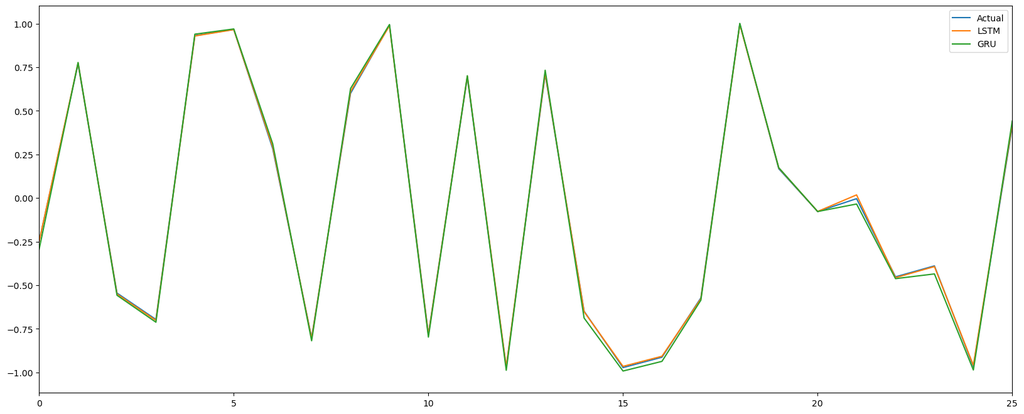

```python
# Plot the actual and predicted values
plt.figure(figsize=(20, 8))
plt.plot(y_test, label='Actual')
plt.xlim(0, 25)
plt.plot(lstm_predictions, label='LSTM')
plt.plot(gru_predictions, label='GRU')
plt.legend()
plt.show()
```

```python
# Build the MLP model
mlp_model = Sequential()
mlp_model.add(Dense(32, activation='relu', input_shape=(1,)))
mlp_model.add(Dense(16, activation='relu'))
mlp_model.add(Dense(1))

# Compile the model
mlp_model.compile(loss='mean_squared_error', optimizer='adam')

# Train the MLP model
mlp_model.fit(X_train, y_train, epochs=50, batch_size=16)

# Evaluate the model
mlp_predictions = mlp_model.predict(X_test.reshape((X_test.shape[0], X_test.shape[1], 1)))
mlp_model_loss = mlp_model.evaluate(X_test, y_test)
print("mlp model loss:", mlp_model_loss)
```

```
mlp model loss: 2.4196066078729928e-05
```

```python
mlp_model.summary()
```

```
Model: "sequential_12"
_________________________________________________________________
 Layer (type)                Output Shape              Param #
=================================================================
 dense_18 (Dense)            (None, 32)                64

 dense_19 (Dense)            (None, 16)                528

 dense_20 (Dense)            (None, 1)                 17

=================================================================
Total params: 609
Trainable params: 609
Non-trainable params: 0
_________________________________________________________________
```

Input layer: The input layer has a single neuron, which accepts a single value. Hidden layer 1: The first hidden layer has 32 neurons, each of which uses a ReLU activation function. Hidden layer 2: The second hidden layer has 16 neurons, each of which uses a ReLU activation function. Output layer: The output layer has a single neuron, which uses a linear activation function.

Number of parametres First layer: The first layer receives an input shape of (1,). Each neuron in this layer is connected to the input, so it has 1 weight for each input feature. Additionally, there is a bias term for each neuron. Hence, the total number of parameters in this layer is: Number of weights = input_shape *units = 1* 32 = 32 Number of biases = units = 32 Total parameters in the first layer = number of weights + number of biases = 32 + 32 = 64

Second layer: The second layer receives the output from the first layer, which is a vector of size 32. Each neuron in this layer is connected to all the neurons in the previous layer, so it has 32 weights (connections) for each input feature. Additionally, there is a bias term for each neuron. Hence, the total number of parameters in this layer is:

Number of weights = previous_layer_units *units = 32* 16 = 512 Number of biases = units = 16 Total parameters in the second layer = number of weights + number of biases = 512 + 16 = 528

Third (output) layer: The output layer receives the output from the second layer, which is a vector of size 16. Each neuron in this layer is connected to all the neurons in the previous layer, so it has 16 weights (connections) for each input feature. Additionally, there is a bias term for each neuron. Hence, the total number of parameters in this layer is: Number of weights = previous_layer_units *units = 16* 1 = 16 Number of biases = units = 1

Total parameters in the third layer = number of weights + number of biases = 16 + 1 = 17

## Hyperpamaters

The hyperparameters for the model were chosen based on the following considerations:

The number of neurons in each layer was chosen based on the size of the input data and the complexity of the task. Since this task is a smooth curve, we do not need large number of neurons and layers. The activation function ReLU was chosen because it is a good choice for general-purpose tasks. It can avoid gradient problems. The loss function mean squared error was chosen because it is a good choice for regression tasks. The optimizer Adam was chosen because it is a good choice for training neural networks efficiently. The number of epochs was chosen based on the amount of training data available and the desired level of accuracy. The batch size was chosen based on the available computing resources. The choice of hyperparameters is a trade-off between accuracy, training time, and computational resources. The best choice of hyperparameters will depend on the specific task and the available resources.

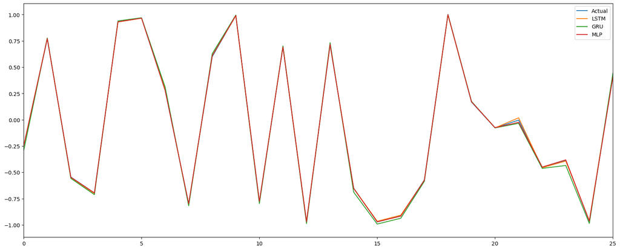

```python
# Plot the actual and predicted values
plt.figure(figsize=(20, 8))
plt.plot(y_test, label='Actual')
plt.xlim(0, 25)
plt.plot(lstm_predictions, label='LSTM')
plt.plot(gru_predictions, label='GRU')
plt.plot(mlp_predictions, label='MLP')

plt.legend()
plt.show()
```

We can see that all neural networks can capture the shape of general Sin function. The MLP and LSTM models has the best performance, followed by GRU.